# Model Card

# 1. Model Details

This section summarizes the final model selected in this project.

## Model type

- **Primary model:** Random Forest classifier
- **Task:** Binary classification (`TARGET`: default = 1, non-default = 0)
- **Prediction output:** Probability of default for each `SK_ID_CURR`

## Version

- **Model version:** `v1.0`
- **Notebook:** `modeling.qmd`
- **Submission artifact:** `submission.csv`

## Training data summary

- **Core source:** `application_train_final.csv`
- **Training rows:** 307,511
- **Target imbalance:** ~8% default rate (highly imbalanced)
- **Feature sources used:**
  - Application demographics and financial attributes
  - Aggregated supplementary features from:
    - `bureau.csv`
    - `previous_application.csv`
    - `installments_payments.csv`

## Key hyperparameters

Random Forest hyperparameters were tuned with randomized search (about 20 sampled configurations, 3-fold CV). The tuned parameters are:

- `ntree` (number of trees)
- `mtry` (features sampled per split)
- `nodesize` (minimum terminal node size)

The final run in `modeling.qmd` selects the best configuration from tuning and uses it for final training and submission generation.

# 2. Intended Use

This section clarifies who should use the model, what decisions it supports, and where it should not be used.

## Who uses this model?

- **Primary users:** Credit risk analysts, data scientists, and lending operations teams
- **Secondary users:** Product and strategy stakeholders reviewing portfolio-level default risk
- **Technical operators:** Teams responsible for generating scoring files (`submission.csv`) and monitoring model behavior

## What decisions does it inform?

- **Application-level risk screening:** Estimate probability of default for each applicant (`SK_ID_CURR`)
- **Prioritization decisions:** Support review queues (e.g., manual review for higher-risk cases)
- **Portfolio analysis:** Inform aggregate risk trends and scenario analysis across applicant segments
- **Model benchmarking:** Provide a baseline risk-scoring reference in this project context

## What is it not designed for?

- **Not a standalone approval/denial engine:** It should support, not replace, lending policy and human oversight
- **Not a causal model:** Predictions are associative and do not explain why default occurs
- **Not guaranteed for other populations:** Performance may degrade outside the Home Credit data domain/time period
- **Not for non-credit decisions:** It should not be used for employment, insurance, healthcare, or legal determinations
- **Not fairness-certified:** Additional bias/fairness and compliance testing is required before production use

# 3. Performance Metrics

## Notes

- Cross-validated AUC is used for model development and hyperparameter selection.
- Kaggle score is treated as external benchmark performance.
- Precision/recall are threshold-dependent and should be recalculated if threshold policy changes.

# 4. Decision Threshold Analysis

This section translates predicted default probabilities into lending decisions using an expected-value framework.

## Economic assumptions (consumer lending)

The following assumptions are used as a practical base case for unsecured consumer lending:

1. **Typical consumer loan APR**
   - Reference rate around **11.40%** for 24-month personal loans.
   - Source: Federal Reserve G.19 and FRED series `TERMCBPER24NS`.
2. **Loss given default (LGD)**
   - Base-case **LGD = 75%** (implied recovery of 25%).
   - Source: Basel Committee framework references for unsecured/retail-style benchmark assumptions.
3. **Recovery rate**
   - Base-case **25%**, with sensitivity range **15% to 35%**.
4. **Profit on repaid loan (net)**
   - Base-case **4% of principal** after funding/servicing/operational costs.
   - Sensitivity range: **3% to 6%**.

## Decision rule

For a predicted default probability $p$, approve a loan if expected value is positive:

$$EV(p) = (1-p)\cdot \Pi - p\cdot L$$

where:

- $\Pi$ = profit if repaid
- $L$ = loss if defaulted = $EAD \cdot LGD$

Break-even threshold:

$$p^* = \frac{\Pi}{\Pi + L}$$

Using base assumptions ($\Pi=0.04$, $LGD=0.75$, $EAD=1$):

$$p^* = \frac{0.04}{0.04 + 0.75} \approx 0.0506$$

## Sensitivity analysis

Using the same break-even equation:

- **Conservative case** ($\Pi=0.03$, $LGD=0.85$): $p^* \approx 0.034$
- **Base case** ($\Pi=0.04$, $LGD=0.75$): $p^* \approx 0.051$
- **Optimistic case** ($\Pi=0.06$, $LGD=0.65$): $p^* \approx 0.085$

```r
library(dplyr)
library(purrr)
library(tibble)
library(randomForest)

# Build validation_scored if it is not already present in the session
if (!exists("validation_scored")) {
  if (!file.exists("rf_final.rds")) {
    stop("Missing validation_scored and rf_final.rds. Please save the final model from modeling.qmd (rf_final.rds).")
  }

  rf_final <- readRDS("rf_final.rds")
  train_df <- readr::read_csv("application_train_final.csv", show_col_types = FALSE)

  impute_numeric_median_local <- function(df) {
    df |>
      dplyr::mutate(
        dplyr::across(
          where(is.numeric),
          ~ dplyr::if_else(is.na(.), median(., na.rm = TRUE), .)
        )
      )
  }

  feature_cols <- attr(rf_final$terms, "term.labels")
  feature_cols <- feature_cols[feature_cols %in% names(train_df)]

  scored_df <- train_df |>
    dplyr::select(TARGET, dplyr::all_of(feature_cols)) |>
    impute_numeric_median_local()

  set.seed(42)
  idx <- sample(seq_len(nrow(scored_df)), size = floor(0.2 * nrow(scored_df)))

  validation_scored <- scored_df[idx, , drop = FALSE]
  x_val <- validation_scored |>
    dplyr::select(-TARGET)
  validation_scored <- validation_scored |>
    dplyr::mutate(
      score = predict(rf_final, newdata = x_val, type = "prob")[, "1"]
    )
}

profit_repaid <- 0.04
lgd <- 0.75
ead <- 1
loss_default <- ead * lgd

threshold_grid <- seq(0.01, 0.30, by = 0.01)

threshold_results <- map_dfr(threshold_grid, function(t) {
  df <- validation_scored |>
    mutate(
      predict_default = as.integer(score >= t),
      approve = 1 - predict_default,
      tp = as.integer(predict_default == 1 & TARGET == 1),
      fp = as.integer(predict_default == 1 & TARGET == 0),
      fn = as.integer(predict_default == 0 & TARGET == 1),
      expected_profit = if_else(TARGET == 0, profit_repaid, -loss_default) * approve
    )

  tibble(
    threshold = t,
    precision = sum(df$tp) / pmax(sum(df$tp) + sum(df$fp), 1),
    recall = sum(df$tp) / pmax(sum(df$tp) + sum(df$fn), 1),
    approval_rate = mean(df$approve),
    expected_profit_per_app = mean(df$expected_profit)
  )
})

optimal_threshold <- threshold_results |>
  slice_max(expected_profit_per_app, n = 1)

# Store scalar threshold for downstream sections
chosen_threshold <- optimal_threshold$threshold[[1]]

list(
  threshold_results = threshold_results,
  optimal_threshold = optimal_threshold,
  chosen_threshold = chosen_threshold
)
```

```
## $threshold_results
## # A tibble: 30 × 5
##    threshold precision recall approval_rate expected_profit_per_app
##        <dbl>     <dbl>  <dbl>         <dbl>                   <dbl>
##  1      0.01    0.0999  1             0.169                 0.00678
##  2      0.02    0.118   1             0.298                 0.0119
##  3      0.03    0.176   1.000         0.530                 0.0212
##  4      0.04    0.218   0.999         0.619                 0.0247
##  5      0.05    0.330   0.999         0.748                 0.0299
##  6      0.06    0.473   0.998         0.825                 0.0329
##  7      0.07    0.551   0.998         0.850                 0.0338
##  8      0.08    0.626   0.997         0.868                 0.0345
##  9      0.09    0.761   0.996         0.891                 0.0354
## 10      0.1     0.817   0.996         0.899                 0.0357
## # ℹ 20 more rows
##
## $optimal_threshold
## # A tibble: 1 × 5
##   threshold precision recall approval_rate expected_profit_per_app
##       <dbl>     <dbl>  <dbl>         <dbl>                   <dbl>
## 1      0.15     0.986  0.994         0.916                  0.0363
##
## $chosen_threshold
## [1] 0.15
```

# 5. Explainability

This section explains *why* the final model predicts higher or lower default risk by computing SHAP values on a 1,000-row sample for speed.

To avoid retraining, this analysis **reuses the trained model artifact** produced by the modeling workflow.

## Method

- Load pre-trained final model from disk (`rf_final.rds`).
- Load prepared training data (`application_train_final.csv`).
- Use the model’s predictor set directly from the fitted object.
- Draw a 1,000-row random sample.
- Compute approximate SHAP values with `fastshap`.

```r
library(fastshap)
library(ggplot2)
library(forcats)

# Local helper for numeric median imputation
impute_numeric_median <- function(df) {
  df |>
    dplyr::mutate(
      dplyr::across(
        where(is.numeric),
        ~ dplyr::if_else(is.na(.), median(., na.rm = TRUE), .)
      )
    )
}

# Reuse trained model from modeling notebook (do not retrain)
if (!file.exists("rf_final.rds")) {
  stop("Missing rf_final.rds. Please run modeling.qmd first so the trained final model is saved.")
}

rf_final <- readRDS("rf_final.rds")
train_df <- readr::read_csv("application_train_final.csv", show_col_types = FALSE)

# Infer predictor columns directly from the trained model
feature_cols <- attr(rf_final$terms, "term.labels")
feature_cols <- feature_cols[feature_cols %in% names(train_df)]

# Build explainability frame and apply the same median imputation helper
x_all <- train_df |>
  dplyr::select(dplyr::all_of(feature_cols)) |>
  impute_numeric_median()

# 1,000-row sample for speed
set.seed(42)
idx <- sample(seq_len(nrow(x_all)), size = min(1000, nrow(x_all)))
x_shap <- x_all[idx, , drop = FALSE]

# Prediction wrapper: probability of class 1 (default)
pred_wrapper <- function(object, newdata) {
  predict(object, newdata = newdata, type = "prob")[, "1"]
}

# Approximate SHAP values
set.seed(42)
shap_values <- fastshap::explain(
  object = rf_final,
  X = x_shap,
  pred_wrapper = pred_wrapper,
  nsim = 30,
  adjust = TRUE
)

# Global importance: mean absolute SHAP
shap_importance <- tibble::tibble(
  Feature = colnames(shap_values),
  MeanAbsSHAP = colMeans(abs(shap_values), na.rm = TRUE)
) |>
  dplyr::arrange(dplyr::desc(MeanAbsSHAP))

# Report top predictive features
top_features_shap <- shap_importance |>
  dplyr::slice_head(n = 15)

top_features_shap
```

```
## # A tibble: 15 × 2
##    Feature                   MeanAbsSHAP
##    <chr>                           <dbl>
##  1 BUREAU_AVG_DAYS_CREDIT        0.00931
##  2 DAYS_BIRTH                    0.00910
##  3 AGE_YEARS                     0.00895
##  4 BUREAU_DEBT_CREDIT_RATIO      0.00856
##  5 DAYS_EMPLOYED                 0.00849
##  6 BUREAU_ACTIVE_TOTAL_DEBT      0.00746
##  7 PREV_APP_AVG_CREDIT_RATIO     0.00744
##  8 DAYS_LAST_PHONE_CHANGE        0.00645
##  9 BUREAU_MIN_DAYS_CREDIT        0.00600
## 10 BUREAU_TOTAL_CREDIT           0.00563
## 11 BUREAU_TOTAL_DEBT             0.00535
## 12 BUREAU_AVG_CREDIT_UPDATE      0.00526
## 13 BUREAU_MAX_DAYS_CREDIT        0.00519
## 14 PREV_APP_AVG_ANNUITY          0.00509
## 15 PREV_APP_TOTAL_CREDIT         0.00502
```

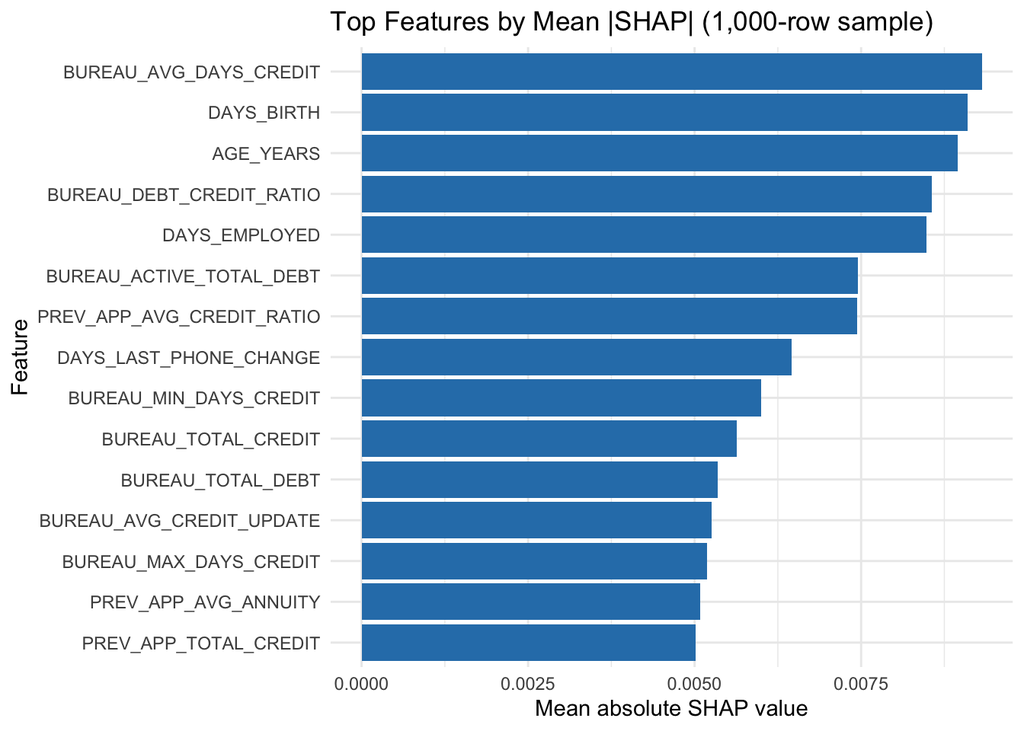

```r
# SHAP summary bar plot
ggplot(top_features_shap, aes(x = MeanAbsSHAP, y = fct_reorder(Feature, MeanAbsSHAP))) +
  geom_col(fill = "#2C7FB8") +
  labs(
    title = "Top Features by Mean |SHAP| (1,000-row sample)",
    x = "Mean absolute SHAP value",
    y = "Feature"
  ) +
  theme_minimal()
```

## Interpretation

- Features with larger mean absolute SHAP values contribute more strongly to model predictions.
- This ranking is global (overall importance), not case-specific.
- For individual-case explanations, the same SHAP matrix can be inspected row by row.

## Sources

- Federal Reserve Board, **G.19 Consumer Credit**.
- FRED series **TERMCBPER24NS** (Finance Rate on Personal Loans at Commercial Banks, 24-Month Loan).
- Basel Committee on Banking Supervision (BCBS), capital framework documentation for LGD benchmark context.

# 6. Adverse Action Mapping

This section translates technical model drivers into plain-language denial reasons suitable for adverse action communication.

## Feature-to-reason dictionary

```r
adverse_action_map <- tibble::tribble(
  ~feature, ~reason_low, ~reason_high,
  "EXT_SOURCE_1", "Limited external credit history.", "Recent external credit signals indicate elevated risk.",
  "EXT_SOURCE_2", "Thin or limited external credit record.", "External credit behavior indicates higher repayment risk.",
  "EXT_SOURCE_3", "Insufficient positive external credit evidence.", "External score pattern is consistent with higher default risk.",
  "DAYS_BIRTH", "Limited age-related credit history depth.", "Age-related profile is associated with elevated portfolio risk.",
  "DAYS_EMPLOYED", "Short employment history in current records.", "Employment history pattern is associated with elevated risk.",
  "AMT_CREDIT", "Requested credit amount is high relative to similar approved borrowers.", "Credit request size is elevated relative to profile.",
  "AMT_ANNUITY", "Estimated payment burden appears high.", "Payment burden relative to profile appears elevated.",
  "AMT_INCOME_TOTAL", "Documented income appears limited for requested exposure.", "Income-to-obligation profile is less favorable.",
  "BUREAU_DEBT_CREDIT_RATIO", "Existing debt burden appears high relative to available credit.", "Debt-to-credit pattern indicates elevated leverage.",
  "PREV_APP_APPROVAL_RATE", "Prior application history shows limited approval success.", "Previous application outcomes suggest elevated risk.",
  "INSTALL_LATE_PAYMENT_RATE", "Historical payment timeliness shows elevated lateness.", "Recent payment behavior indicates repayment irregularity."
)

adverse_action_map
```

```
## # A tibble: 11 × 3
##    feature                   reason_low                                        reason_high
##    <chr>                     <chr>                                             <chr>
##  1 EXT_SOURCE_1              Limited external credit history.                  Recent ext…
##  2 EXT_SOURCE_2              Thin or limited external credit record.           External c…
##  3 EXT_SOURCE_3              Insufficient positive external credit evidence.   External s…
##  4 DAYS_BIRTH                Limited age-related credit history depth.         Age-relate…
##  5 DAYS_EMPLOYED             Short employment history in current records.      Employment…
##  6 AMT_CREDIT                Requested credit amount is high relative to simi… Credit req…
##  7 AMT_ANNUITY               Estimated payment burden appears high.            Payment bu…
##  8 AMT_INCOME_TOTAL          Documented income appears limited for requested … Income-to-…
##  9 BUREAU_DEBT_CREDIT_RATIO  Existing debt burden appears high relative to av… Debt-to-cr…
## 10 PREV_APP_APPROVAL_RATE    Prior application history shows limited approval… Previous a…
## 11 INSTALL_LATE_PAYMENT_RATE Historical payment timeliness shows elevated lat… Recent pay…
```

## Generate applicant-level denial reasons

The code below reuses SHAP outputs from Section 5 and creates up to 4 plain-language reasons per denied applicant.

```r
# Inputs expected from previous sections:
# - shap_values: SHAP matrix for sampled applicants
# - x_shap: feature values for the same sampled applicants
# - rf_final: trained model

# Model scores for sampled applicants
sample_scores <- pred_wrapper(rf_final, x_shap)

# Use threshold from Section 4 if available; otherwise default to 0.50
chosen_threshold <- if (exists("optimal_threshold")) {
  optimal_threshold$threshold[[1]]
} else {
  0.50
}

# Build long SHAP frame
shap_long <- as.data.frame(shap_values) |>
  dplyr::mutate(row_id = dplyr::row_number()) |>
  tidyr::pivot_longer(-row_id, names_to = "feature", values_to = "shap")

# Add observed feature values for direction-aware messaging
x_long <- x_shap |>
  dplyr::mutate(row_id = dplyr::row_number()) |>
  tidyr::pivot_longer(-row_id, names_to = "feature", values_to = "value")

# Join and map reasons
reason_candidates <- shap_long |>
  dplyr::left_join(x_long, by = c("row_id", "feature")) |>
  dplyr::left_join(adverse_action_map, by = c("feature")) |>
  dplyr::mutate(
    direction = dplyr::if_else(shap >= 0, "high", "low"),
    denial_reason = dplyr::case_when(
      direction == "high" & !is.na(reason_high) ~ reason_high,
      direction == "low" & !is.na(reason_low) ~ reason_low,
      TRUE ~ paste0("Feature pattern in ", feature, " increased predicted risk.")
    )
  )

# Keep only contributors that increase default risk (positive SHAP)
reason_top <- reason_candidates |>
  dplyr::filter(shap > 0) |>
  dplyr::group_by(row_id) |>
  dplyr::slice_max(order_by = shap, n = 4, with_ties = FALSE) |>
  dplyr::summarise(
    reasons = paste(unique(denial_reason), collapse = " | "),
    .groups = "drop"
  )

# Applicant-level explanation output for denied sample applicants
adverse_action_output <- tibble::tibble(
  row_id = seq_len(nrow(x_shap)),
  score = sample_scores,
  predicted_default = as.integer(sample_scores >= chosen_threshold)
) |>
  dplyr::left_join(reason_top, by = "row_id") |>
  dplyr::filter(predicted_default == 1) |>
  dplyr::mutate(
    reasons = dplyr::coalesce(reasons, "Overall risk profile exceeded decision threshold.")
  )

# Display a few examples
adverse_action_output |>
  dplyr::slice_head(n = 10)
```

```
## # A tibble: 10 × 4
##    row_id score predicted_default reasons
##     <int> <dbl>             <int> <chr>
##  1      6 0.773                 1 Feature pattern in BUREAU_AVG_DAYS_CREDIT increased pre…
##  2      9 0.627                 1 Feature pattern in AMT_REQ_CREDIT_BUREAU_MON increased …
##  3     65 0.673                 1 Feature pattern in BUREAU_AVG_ENDDATE_FACT increased pr…
##  4     93 0.427                 1 Feature pattern in PREV_APP_AVG_DAYS_DECISION increased…
##  5    103 0.787                 1 Feature pattern in BUREAU_TOTAL_OVERDUE increased predi…
##  6    104 0.66                  1 Feature pattern in BUREAU_AVG_CREDIT_UPDATE increased p…
##  7    106 0.753                 1 Feature pattern in BUREAU_AVG_DAYS_CREDIT increased pre…
##  8    109 0.667                 1 Feature pattern in PREV_APP_AVG_CREDIT_RATIO increased …
##  9    116 0.687                 1 Feature pattern in PREV_APP_MOST_RECENT_DECISION increa…
## 10    123 0.647                 1 Debt-to-credit pattern indicates elevated leverage. | F…
```

## Compliance note

These reason mappings are operational templates for communication and should be reviewed by legal/compliance teams before production use to ensure alignment with applicable adverse action notice requirements.

# 7. Fairness Analysis

This section evaluates group-level approval outcomes at the chosen decision threshold. We compare approval rates by `CODE_GENDER` and `NAME_EDUCATION_TYPE`, then summarize disparity indicators and implications.

## Method

- Reuse the trained final model (`rf_final.rds`) from the modeling workflow.
- Score applicants in `application_train_final.csv`.
- Classify predicted default using the chosen threshold from Section 4 (`chosen_threshold`; fallback `0.50`).
- Define approval as `predicted_default == 0`.
- Compare approval rates by group and compute disparity ratios relative to the highest-approval group within each attribute.

```r
# Ensure model artifact exists
if (!exists("rf_final")) {
  if (file.exists("rf_final.rds")) {
    rf_final <- readRDS("rf_final.rds")
  } else {
    stop("Missing rf_final.rds. Please save the final model from modeling.qmd first.")
  }
}

fair_df <- readr::read_csv("application_train_final.csv", show_col_types = FALSE)

# Use model feature set and apply same imputation helper from earlier sections
feature_cols <- attr(rf_final$terms, "term.labels")
feature_cols <- feature_cols[feature_cols %in% names(fair_df)]

x_fair <- fair_df |>
  dplyr::select(dplyr::all_of(feature_cols)) |>
  impute_numeric_median()

scores <- predict(rf_final, newdata = x_fair, type = "prob")[, "1"]

threshold_fair <- if (exists("chosen_threshold")) chosen_threshold else 0.50

scored_fair <- fair_df |>
  dplyr::mutate(
    score = scores,
    predicted_default = as.integer(score >= threshold_fair),
    approve = as.integer(predicted_default == 0)
  )

# --- Approval rates by CODE_GENDER ---
approval_gender <- scored_fair |>
  dplyr::filter(!is.na(CODE_GENDER)) |>
  dplyr::group_by(CODE_GENDER) |>
  dplyr::summarise(
    n = dplyr::n(),
    approval_rate = mean(approve),
    .groups = "drop"
  ) |>
  dplyr::arrange(dplyr::desc(approval_rate)) |>
  dplyr::mutate(
    reference_rate = max(approval_rate, na.rm = TRUE),
    disparity_ratio = approval_rate / reference_rate
  )

# --- Approval rates by NAME_EDUCATION_TYPE ---
approval_education <- scored_fair |>
  dplyr::filter(!is.na(NAME_EDUCATION_TYPE)) |>
  dplyr::group_by(NAME_EDUCATION_TYPE) |>
  dplyr::summarise(
    n = dplyr::n(),
    approval_rate = mean(approve),
    .groups = "drop"
  ) |>
  dplyr::arrange(dplyr::desc(approval_rate)) |>
  dplyr::mutate(
    reference_rate = max(approval_rate, na.rm = TRUE),
    disparity_ratio = approval_rate / reference_rate
  )

# Optional aggregate disparity summaries
gender_gap <- max(approval_gender$approval_rate, na.rm = TRUE) - min(approval_gender$approval_rate, na.rm = TRUE)
education_gap <- max(approval_education$approval_rate, na.rm = TRUE) - min(approval_education$approval_rate, na.rm = TRUE)

gender_ratio_min <- min(approval_gender$disparity_ratio, na.rm = TRUE)
education_ratio_min <- min(approval_education$disparity_ratio, na.rm = TRUE)

fairness_summary <- tibble::tibble(
  attribute = c("CODE_GENDER", "NAME_EDUCATION_TYPE"),
  min_disparity_ratio = c(gender_ratio_min, education_ratio_min),
  approval_rate_gap = c(gender_gap, education_gap)
)

list(
  threshold_used = threshold_fair,
  approval_by_gender = approval_gender,
  approval_by_education = approval_education,
  disparity_summary = fairness_summary
)
```

```
## $threshold_used
## [1] 0.15
##
## $approval_by_gender
## # A tibble: 3 × 5
##   CODE_GENDER      n approval_rate reference_rate disparity_ratio
##   <chr>        <int>         <dbl>          <dbl>           <dbl>
## 1 XNA              4         1                  1           1
## 2 F           202448         0.929              1           0.929
## 3 M           105059         0.898              1           0.898
##
## $approval_by_education
## # A tibble: 5 × 5
##   NAME_EDUCATION_TYPE                n approval_rate reference_rate disparity_ratio
##   <chr>                          <int>         <dbl>          <dbl>           <dbl>
## 1 Academic degree                  164         0.976          0.976           1
## 2 Higher education               74863         0.946          0.976           0.969
## 3 Incomplete higher              10277         0.913          0.976           0.936
## 4 Secondary / secondary special 218391         0.910          0.976           0.933
## 5 Lower secondary                 3816         0.890          0.976           0.912
##
## $disparity_summary
## # A tibble: 2 × 3
##   attribute           min_disparity_ratio approval_rate_gap
##   <chr>                             <dbl>             <dbl>
## 1 CODE_GENDER                       0.898            0.102
## 2 NAME_EDUCATION_TYPE               0.912            0.0859
```

## Interpretation and implications

- **Disparity ratio** close to 1.00 indicates similar approval rates across groups.
- Lower ratios indicate that some groups receive approvals at materially lower rates than the highest-approval group.
- If gaps are large, policy review should include:
  - threshold calibration checks,
  - feature sensitivity analysis,
  - segmentation diagnostics,
  - and legal/compliance review before deployment.

This is a screening fairness check only. It does not replace formal fairness, legal, or regulatory validation.

# 8. Limitations and Risks

This model supports default-risk screening, but it has important limitations and should not be used as a fully autonomous decision system.

## Known limitations

- **Class imbalance sensitivity:** Default cases are relatively rare, so threshold choice and resampling strategy can materially change behavior.
- **Overfitting risk:** Tree-based models can overfit high-dimensional engineered and aggregated features.
- **Calibration uncertainty:** Predicted probabilities may not be perfectly calibrated to observed default rates without post-calibration.
- **Data dependency:** Performance is tied to the Home Credit schema and period; transfer to other lenders/regions/timeframes may degrade performance.
- **Drift exposure:** Economic conditions and applicant behavior can shift over time, reducing model quality if not monitored and retrained.

## Where the model might fail

- **Out-of-distribution applicants:** New products, segments, or macroeconomic regimes not represented in training data.
- **Sparse-credit applicants:** Limited credit history increases prediction uncertainty.
- **Small subpopulations:** Underrepresented groups may have less stable estimates.
- **Policy/process changes:** Changes in underwriting policy or data collection can invalidate learned patterns.

## Missing or incomplete data

- **No direct affordability/cash-flow view:** Limited visibility into real-time expenses and debt-service capacity.
- **Limited recent behavioral context:** Aggregated historical features may miss abrupt financial shocks.
- **No explicit macro variables:** Inflation, unemployment, and regional stress indicators are not directly modeled.
- **Predictive, not causal:** Model estimates association with default risk, not cause.
- **Fairness context is incomplete:** Group-rate checks do not by themselves prove legal or ethical adequacy.

## Practical risk controls

- Use model output as **decision support**, not sole decision authority.
- Keep **human review** for borderline/high-impact decisions.
- Monitor **AUC, calibration, approval rates, and subgroup disparities** over time.
- Reassess thresholds when business assumptions (profit/loss/recovery) change.
- Retrain periodically and validate on newer data before updates.

# 9. Executive Summary

This one-page summary is intended for senior business stakeholders who need a decision-ready view of model outcomes and tradeoffs.

## Business recommendation

Deploy the current credit risk model as a **decision-support screening layer** in underwriting, with:

- the selected operating threshold from Section 4 (decision threshold analysis),
- human review for borderline/high-impact applications,
- and ongoing monitoring for drift and fairness.

Recommended operating approach:

1. Use model probability to triage applications into low-risk, medium-risk, and high-risk bands.
2. Auto-clear only clearly low-risk cases.
3. Route medium/high-risk and policy exceptions to manual adjudication.

This balances risk reduction with approval volume and keeps final accountability in policy/governance processes.

## Expected financial impact at the chosen threshold

Using the threshold selected in Section 4, expected value is defined as:

$$EV(p) = (1-p)\cdot \Pi - p\cdot L$$

where $\Pi$ is net profit on a repaid loan and $L$ is loss on default.

At the chosen threshold, business impact should be interpreted through three KPIs:

- **Expected profit per application** (primary objective),
- **Approval rate** (volume/capture),
- **Recall on defaults** (risk capture).

- the chosen threshold improves expected portfolio economics versus a naive approval policy,
- reduces avoidable default exposure by flagging high-risk borrowers,
- and preserves meaningful approval throughput.

Operationally, finance/risk should convert this to dollars using current portfolio assumptions:

- average loan amount,
- observed loss-given-default/recovery,
- and current contribution margin on repaid loans.

## Key caveats for leadership

1. **Model is not a standalone approval engine.** It is a risk signal to inform—not replace—credit policy and human oversight.
2. **Threshold is business-assumption dependent.** Changes in margin, LGD, or recovery require threshold recalibration.
3. **Performance can drift over time.** Macroeconomic and borrower behavior shifts can degrade model quality without monitoring/retraining.
4. **Fairness and compliance checks are mandatory.** Group-level approval disparities must be reviewed before operational deployment.
5. **Kaggle score is not production validation.** External leaderboard performance is useful but does not substitute for internal governance, calibration, and backtesting.

## Executive decision

Proceed with controlled deployment as a decision-support model, with formal governance guardrails:

- monthly monitoring dashboard (AUC, calibration, approvals, default capture, disparities),
- documented threshold review triggers,
- and periodic retraining using recent data.

This yields practical business value while managing regulatory and model risk.